# Programming Assignment: Build a CNN for image recognition.

### Name: Xi Ting Yang

## 0. You will do the following:

1. Read, complete, and run the code.
2. **Make substantial improvements** to maximize the accuracy.
3. Convert the .IPYNB file to .HTML file.
   - The HTML file must contain the code and the output after execution.
   - Missing **the output after execution** will not be graded.
4. Upload the .HTML file to your Google Drive, Dropbox, or Github repo. (If you submit the file to Google Drive or Dropbox, you must make the file "open-access". The delay caused by "deny of access" may result in late penalty.)
5. On Canvas, submit the Google Drive/Dropbox/Github link to the HTML file.

## Requirements:

1. You can use whatever CNN architecture, including VGG, Inception, and ResNet. However, you must build the networks layer by layer. You must NOT import the archetectures from `keras.applications`.
2. Make sure `BatchNormalization` is between a `Conv`/`Dense` layer and an `activation` layer.
3. If you want to regularize a `Conv`/`Dense` layer, you should place a `Dropout` layer **before** the `Conv`/`Dense` layer.
4. An accuracy above 70% is considered reasonable. An accuracy above 80% is considered good. Without data augmentation, achieving 80% accuracy is difficult.

## Google Colab

- If you do not have GPU, the training of a CNN can be slow. Google Colab is a good option.
- Keep in mind that you must download it as an IPYNB file and then use IPython Notebook to convert it to HTML.
- Also keep in mind that the IPYNB and HTML files must contain the outputs. (Otherwise, the instructor will not be able to know the correctness and performance.) Do the followings to keep the outputs.
- In Colab, go to `Runtime` --> `Change runtime type` --> Do NOT check `Omit code cell output when saving this notebook`. In this way, the downloaded IPYNB file contains the outputs.

## 1. Data preparation

### 1.1. Load data

```python
from keras.datasets import cifar10
import numpy as np

(x_train, y_train), (x_test, y_test) = cifar10.load_data()

print('shape of x_train: ' + str(x_train.shape))
print('shape of y_train: ' + str(y_train.shape))
print('shape of x_test: ' + str(x_test.shape))
print('shape of y_test: ' + str(y_test.shape))
print('number of classes: ' + str(np.max(y_train) - np.min(y_train) + 1))
```

```
Downloading data from https://www.cs.toronto.edu/~kriz/cifar-10-python.tar.gz
170498071/170498071 ━━━━━━━━━━━━━━━━━━━━ 6s 0us/step
shape of x_train: (50000, 32, 32, 3)
shape of y_train: (50000, 1)
shape of x_test: (10000, 32, 32, 3)
shape of y_test: (10000, 1)
number of classes: 10
```

### 1.2. One-hot encode the labels

In the input, a label is a scalar in $\{0, 1, \cdots , 9\}$. One-hot encode transform such a scalar to a $10$-dim vector. E.g., a scalar `y_train[j]=3` is transformed to the vector `y_train_vec[j]=[0, 0, 0, 1, 0, 0, 0, 0, 0, 0]`.

1. Define a function `to_one_hot` that transforms an $n\times 1$ array to a $n\times 10$ matrix.
2. Apply the function to `y_train` and `y_test`.

```python
def to_one_hot(y, num_class=10):
   y = y.reshape(-1)
   one_hot=np.zeros((y.size,num_class))
   one_hot[np.arange(y.size),y]=1
   return one_hot

y_train_vec = to_one_hot(y_train)
y_test_vec = to_one_hot(y_test)

print('Shape of y_train_vec: ' + str(y_train_vec.shape))
print('Shape of y_test_vec: ' + str(y_test_vec.shape))

print(y_train[0])
print(y_train_vec[0])
```

```
Shape of y_train_vec: (50000, 10)
Shape of y_test_vec: (10000, 10)
[6]
[0. 0. 0. 0. 0. 0. 1. 0. 0. 0.]
```

#### Remark: the outputs should be

- Shape of y_train_vec: (50000, 10)
- Shape of y_test_vec: (10000, 10)
- [6]
- [0. 0. 0. 0. 0. 0. 1. 0. 0. 0.]

### 1.3. Randomly partition the training set to training and validation sets

Randomly partition the 50K training samples to 2 sets:

- a training set containing 40K samples
- a validation set containing 10K samples

```python
rand_indices = np.random.permutation(50000)
train_indices = rand_indices[0:40000]
valid_indices = rand_indices[40000:50000]

x_val = x_train[valid_indices, :]
y_val = y_train_vec[valid_indices, :]

x_tr = x_train[train_indices, :]
y_tr = y_train_vec[train_indices, :]

print('Shape of x_tr: ' + str(x_tr.shape))
print('Shape of y_tr: ' + str(y_tr.shape))
print('Shape of x_val: ' + str(x_val.shape))
print('Shape of y_val: ' + str(y_val.shape))
```

```
Shape of x_tr: (40000, 32, 32, 3)
Shape of y_tr: (40000, 10)
Shape of x_val: (10000, 32, 32, 3)
Shape of y_val: (10000, 10)
```

## 2. Build a CNN and tune its hyper-parameters

1. Build a convolutional neural network model
2. Use the validation data to tune the hyper-parameters (e.g., network structure, and optimization algorithm)
   - Do NOT use test data for hyper-parameter tuning!!!
3. Try to achieve a validation accuracy as high as possible.

### Remark:

The following CNN is just an example. You are supposed to make **substantial improvements** such as:

- Add more layers.
- Use regularizations, e.g., dropout.
- Use batch normalization.

## Orginal model

```python
from keras.layers import Conv2D, MaxPooling2D, Flatten, Dense
from keras.models import Sequential

model = Sequential()
model.add(Conv2D(32, (3, 3), activation='relu', padding='same', input_shape=(32, 32, 3)))
model.add(MaxPooling2D((2, 2)))
model.add(Conv2D(64, (3, 3), activation='relu', padding='same'))
model.add(MaxPooling2D((2, 2)))
model.add(Flatten())
model.add(Dense(128, activation='relu'))
model.add(Dense(10, activation='softmax'))

model.summary()
```

```
Model: "sequential"
```

```
┏━━━━━━━━━━━━━━━━━━━━━━━━━━━━━━━━━━━━━━┳━━━━━━━━━━━━━━━━━━━━━━━━━━━━━┳━━━━━━━━━━━━━━━━━┓
┃ Layer (type)                         ┃ Output Shape                ┃         Param # ┃
┡━━━━━━━━━━━━━━━━━━━━━━━━━━━━━━━━━━━━━━╇━━━━━━━━━━━━━━━━━━━━━━━━━━━━━╇━━━━━━━━━━━━━━━━━┩
│ conv2d (Conv2D)                      │ (None, 32, 32, 32)          │             896 │
├──────────────────────────────────────┼─────────────────────────────┼─────────────────┤
│ max_pooling2d (MaxPooling2D)         │ (None, 16, 16, 32)          │               0 │
├──────────────────────────────────────┼─────────────────────────────┼─────────────────┤
│ conv2d_1 (Conv2D)                    │ (None, 16, 16, 64)          │          18,496 │
├──────────────────────────────────────┼─────────────────────────────┼─────────────────┤
│ max_pooling2d_1 (MaxPooling2D)       │ (None, 8, 8, 64)            │               0 │
├──────────────────────────────────────┼─────────────────────────────┼─────────────────┤
│ flatten (Flatten)                    │ (None, 4096)                │               0 │
├──────────────────────────────────────┼─────────────────────────────┼─────────────────┤
│ dense (Dense)                        │ (None, 128)                 │         524,416 │
├──────────────────────────────────────┼─────────────────────────────┼─────────────────┤
│ dense_1 (Dense)                      │ (None, 10)                  │           1,290 │
└──────────────────────────────────────┴─────────────────────────────┴─────────────────┘
```

```
 Total params: 545,098 (2.08 MB)
```

```
 Trainable params: 545,098 (2.08 MB)
```

```
 Non-trainable params: 0 (0.00 B)
```

```python
from keras import optimizers

learning_rate = 1E-5 # to be tuned!

model.compile(loss='categorical_crossentropy',
              optimizer=optimizers.RMSprop(learning_rate=learning_rate),
              metrics=['acc'])
history = model.fit(x_tr, y_tr, batch_size=32, epochs=10, validation_data=(x_val, y_val))
```

```
1250/1250 ━━━━━━━━━━━━━━━━━━━━ 17s 12ms/step - acc: 0.2289 - loss: 5.3194 - val_acc: 0.2779 - val_loss: 3.3387
1250/1250 ━━━━━━━━━━━━━━━━━━━━ 19s 15ms/step - acc: 0.3072 - loss: 2.8224 - val_acc: 0.3328 - val_loss: 2.4850
1250/1250 ━━━━━━━━━━━━━━━━━━━━ 19s 15ms/step - acc: 0.3526 - loss: 2.2515 - val_acc: 0.3649 - val_loss: 2.1239
1250/1250 ━━━━━━━━━━━━━━━━━━━━ 19s 15ms/step - acc: 0.3880 - loss: 1.9814 - val_acc: 0.3876 - val_loss: 1.9672
1250/1250 ━━━━━━━━━━━━━━━━━━━━ 19s 15ms/step - acc: 0.4189 - loss: 1.8161 - val_acc: 0.4114 - val_loss: 1.8542
1250/1250 ━━━━━━━━━━━━━━━━━━━━ 18s 15ms/step - acc: 0.4464 - loss: 1.7005 - val_acc: 0.4333 - val_loss: 1.7485
1250/1250 ━━━━━━━━━━━━━━━━━━━━ 18s 15ms/step - acc: 0.4692 - loss: 1.6101 - val_acc: 0.4498 - val_loss: 1.6948
1250/1250 ━━━━━━━━━━━━━━━━━━━━ 19s 15ms/step - acc: 0.4886 - loss: 1.5348 - val_acc: 0.4657 - val_loss: 1.6313
1250/1250 ━━━━━━━━━━━━━━━━━━━━ 19s 15ms/step - acc: 0.5062 - loss: 1.4723 - val_acc: 0.4776 - val_loss: 1.5833
1250/1250 ━━━━━━━━━━━━━━━━━━━━ 18s 14ms/step - acc: 0.5225 - loss: 1.4182 - val_acc: 0.4840 - val_loss: 1.5728
```

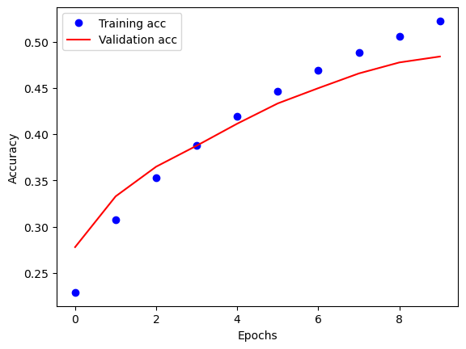

```python
import matplotlib.pyplot as plt
%matplotlib inline

acc = history.history['acc']
val_acc = history.history['val_acc']

epochs = range(len(acc))

plt.plot(epochs, acc, 'bo', label='Training acc')
plt.plot(epochs, val_acc, 'r', label='Validation acc')
plt.xlabel('Epochs')
plt.ylabel('Accuracy')
plt.legend()
plt.show()
```

## Discussion

The above plot shows that the model is underfitted and not converged. Model needs to be deeper, and more iteration.

## Adding Dropout

Performance is not satisfactory due to model being too shallow to dropout neurons.

```python
from keras.layers import Conv2D, MaxPooling2D, Flatten, Dense
from keras.models import Sequential

model = Sequential()
model.add(Conv2D(32, (3, 3), activation='relu', padding='same', input_shape=(32, 32, 3)))
model.add(MaxPooling2D((2, 2)))
model.add(Conv2D(64, (3, 3), activation='relu', padding='same'))
model.add(MaxPooling2D((2, 2)))
model.add(Flatten())
model.add(layers.Dropout(0.5))

model.add(Dense(128, activation='relu'))
model.add(Dense(10, activation='softmax'))

model.summary()

from keras import optimizers

learning_rate = 1E-5 # to be tuned!

model.compile(loss='categorical_crossentropy',
              optimizer=optimizers.RMSprop(learning_rate=learning_rate),
              metrics=['acc'])
history = model.fit(x_tr, y_tr, batch_size=32, epochs=10, validation_data=(x_val, y_val))
```

```
Model: "sequential_5"
```

```
┏━━━━━━━━━━━━━━━━━━━━━━━━━━━━━━━━━━━━━━┳━━━━━━━━━━━━━━━━━━━━━━━━━━━━━┳━━━━━━━━━━━━━━━━━┓
┃ Layer (type)                         ┃ Output Shape                ┃         Param # ┃
┡━━━━━━━━━━━━━━━━━━━━━━━━━━━━━━━━━━━━━━╇━━━━━━━━━━━━━━━━━━━━━━━━━━━━━╇━━━━━━━━━━━━━━━━━┩
│ conv2d_10 (Conv2D)                   │ (None, 32, 32, 32)          │             896 │
├──────────────────────────────────────┼─────────────────────────────┼─────────────────┤
│ max_pooling2d_10 (MaxPooling2D)      │ (None, 16, 16, 32)          │               0 │
├──────────────────────────────────────┼─────────────────────────────┼─────────────────┤
│ conv2d_11 (Conv2D)                   │ (None, 16, 16, 64)          │          18,496 │
├──────────────────────────────────────┼─────────────────────────────┼─────────────────┤
│ max_pooling2d_11 (MaxPooling2D)      │ (None, 8, 8, 64)            │               0 │
├──────────────────────────────────────┼─────────────────────────────┼─────────────────┤
│ flatten_5 (Flatten)                  │ (None, 4096)                │               0 │
├──────────────────────────────────────┼─────────────────────────────┼─────────────────┤
│ dropout_3 (Dropout)                  │ (None, 4096)                │               0 │
├──────────────────────────────────────┼─────────────────────────────┼─────────────────┤
│ dense_10 (Dense)                     │ (None, 128)                 │         524,416 │
├──────────────────────────────────────┼─────────────────────────────┼─────────────────┤
│ dense_11 (Dense)                     │ (None, 10)                  │           1,290 │
└──────────────────────────────────────┴─────────────────────────────┴─────────────────┘
```

```
 Total params: 545,098 (2.08 MB)
```

```
 Trainable params: 545,098 (2.08 MB)
```

```
 Non-trainable params: 0 (0.00 B)
```

```
1250/1250 ━━━━━━━━━━━━━━━━━━━━ 19s 14ms/step - acc: 0.1172 - loss: 11.7824 - val_acc: 0.0984 - val_loss: 2.3023
1250/1250 ━━━━━━━━━━━━━━━━━━━━ 19s 15ms/step - acc: 0.1043 - loss: 2.3804 - val_acc: 0.0981 - val_loss: 2.3026
1250/1250 ━━━━━━━━━━━━━━━━━━━━ 20s 16ms/step - acc: 0.1040 - loss: 2.3312 - val_acc: 0.0980 - val_loss: 2.3025
1250/1250 ━━━━━━━━━━━━━━━━━━━━ 20s 16ms/step - acc: 0.1053 - loss: 2.3205 - val_acc: 0.0993 - val_loss: 2.3018
1250/1250 ━━━━━━━━━━━━━━━━━━━━ 19s 15ms/step - acc: 0.1076 - loss: 2.3157 - val_acc: 0.1026 - val_loss: 2.2986
1250/1250 ━━━━━━━━━━━━━━━━━━━━ 20s 16ms/step - acc: 0.1142 - loss: 2.3132 - val_acc: 0.1091 - val_loss: 2.2922
1250/1250 ━━━━━━━━━━━━━━━━━━━━ 24s 19ms/step - acc: 0.1185 - loss: 2.3047 - val_acc: 0.1175 - val_loss: 2.2787
1250/1250 ━━━━━━━━━━━━━━━━━━━━ 20s 16ms/step - acc: 0.1294 - loss: 2.2857 - val_acc: 0.1291 - val_loss: 2.2396
1250/1250 ━━━━━━━━━━━━━━━━━━━━ 21s 17ms/step - acc: 0.1394 - loss: 2.2625 - val_acc: 0.1451 - val_loss: 2.1944
1250/1250 ━━━━━━━━━━━━━━━━━━━━ 20s 16ms/step - acc: 0.1704 - loss: 2.2324 - val_acc: 0.2043 - val_loss: 2.1512
```

### Adding Batch Normalization

2 convolution layers with batch mornalization and maxpooling respectively Performance improved.

```python
from keras.layers import Conv2D, MaxPooling2D, Flatten, Dense
from keras.models import Sequential
from keras import layers
model = Sequential()
# model.add(Conv2D(32, (3, 3), activation='relu', padding='same', input_shape=(32, 32, 3)))
model.add(Conv2D(32, (3, 3), padding='same', input_shape=(32, 32, 3)))
model.add(layers.BatchNormalization())
model.add(layers.Activation('relu'))
model.add(MaxPooling2D((2, 2)))
model.add(Conv2D(64, (3, 3), padding='same'))
model.add(layers.BatchNormalization())
model.add(layers.Activation('relu'))

model.add(MaxPooling2D((2, 2)))
model.add(Flatten())
model.add(Dense(128, activation='relu'))
model.add(Dense(10, activation='softmax'))

model.summary()
```

```
Model: "sequential_1"
```

```
┏━━━━━━━━━━━━━━━━━━━━━━━━━━━━━━━━━━━━━━┳━━━━━━━━━━━━━━━━━━━━━━━━━━━━━┳━━━━━━━━━━━━━━━━━┓
┃ Layer (type)                         ┃ Output Shape                ┃         Param # ┃
┡━━━━━━━━━━━━━━━━━━━━━━━━━━━━━━━━━━━━━━╇━━━━━━━━━━━━━━━━━━━━━━━━━━━━━╇━━━━━━━━━━━━━━━━━┩
│ conv2d_2 (Conv2D)                    │ (None, 32, 32, 32)          │             896 │
├──────────────────────────────────────┼─────────────────────────────┼─────────────────┤
│ batch_normalization                  │ (None, 32, 32, 32)          │             128 │
│ (BatchNormalization)                 │                             │                 │
├──────────────────────────────────────┼─────────────────────────────┼─────────────────┤
│ activation (Activation)              │ (None, 32, 32, 32)          │               0 │
├──────────────────────────────────────┼─────────────────────────────┼─────────────────┤
│ max_pooling2d_2 (MaxPooling2D)       │ (None, 16, 16, 32)          │               0 │
├──────────────────────────────────────┼─────────────────────────────┼─────────────────┤
│ conv2d_3 (Conv2D)                    │ (None, 16, 16, 64)          │          18,496 │
├──────────────────────────────────────┼─────────────────────────────┼─────────────────┤
│ batch_normalization_1                │ (None, 16, 16, 64)          │             256 │
│ (BatchNormalization)                 │                             │                 │
├──────────────────────────────────────┼─────────────────────────────┼─────────────────┤
│ activation_1 (Activation)            │ (None, 16, 16, 64)          │               0 │
├──────────────────────────────────────┼─────────────────────────────┼─────────────────┤
│ max_pooling2d_3 (MaxPooling2D)       │ (None, 8, 8, 64)            │               0 │
├──────────────────────────────────────┼─────────────────────────────┼─────────────────┤
│ flatten_1 (Flatten)                  │ (None, 4096)                │               0 │
├──────────────────────────────────────┼─────────────────────────────┼─────────────────┤
│ dense_2 (Dense)                      │ (None, 128)                 │         524,416 │
├──────────────────────────────────────┼─────────────────────────────┼─────────────────┤
│ dense_3 (Dense)                      │ (None, 10)                  │           1,290 │
└──────────────────────────────────────┴─────────────────────────────┴─────────────────┘
```

```
 Total params: 545,482 (2.08 MB)
```

```
 Trainable params: 545,290 (2.08 MB)
```

```
 Non-trainable params: 192 (768.00 B)
```

```python
from keras import optimizers

learning_rate = 1e-5 # to be tuned!

model.compile(loss='categorical_crossentropy',
              optimizer=optimizers.RMSprop(learning_rate=learning_rate),
              metrics=['acc'])
history = model.fit(x_tr, y_tr, batch_size=32, epochs=10, validation_data=(x_val, y_val))
```

```
1250/1250 ━━━━━━━━━━━━━━━━━━━━ 59s 43ms/step - acc: 0.3262 - loss: 1.8735 - val_acc: 0.4123 - val_loss: 1.6492
1250/1250 ━━━━━━━━━━━━━━━━━━━━ 51s 41ms/step - acc: 0.4414 - loss: 1.5727 - val_acc: 0.4733 - val_loss: 1.4993
1250/1250 ━━━━━━━━━━━━━━━━━━━━ 54s 43ms/step - acc: 0.4873 - loss: 1.4476 - val_acc: 0.5067 - val_loss: 1.4087
1250/1250 ━━━━━━━━━━━━━━━━━━━━ 51s 40ms/step - acc: 0.5208 - loss: 1.3621 - val_acc: 0.5285 - val_loss: 1.3420
1250/1250 ━━━━━━━━━━━━━━━━━━━━ 52s 41ms/step - acc: 0.5433 - loss: 1.2964 - val_acc: 0.5491 - val_loss: 1.2948
1250/1250 ━━━━━━━━━━━━━━━━━━━━ 52s 42ms/step - acc: 0.5669 - loss: 1.2449 - val_acc: 0.5586 - val_loss: 1.2594
1250/1250 ━━━━━━━━━━━━━━━━━━━━ 53s 42ms/step - acc: 0.5817 - loss: 1.2013 - val_acc: 0.5708 - val_loss: 1.2255
1250/1250 ━━━━━━━━━━━━━━━━━━━━ 52s 41ms/step - acc: 0.5960 - loss: 1.1621 - val_acc: 0.5824 - val_loss: 1.2022
1250/1250 ━━━━━━━━━━━━━━━━━━━━ 50s 40ms/step - acc: 0.6090 - loss: 1.1284 - val_acc: 0.5883 - val_loss: 1.1717
1250/1250 ━━━━━━━━━━━━━━━━━━━━ 51s 41ms/step - acc: 0.6217 - loss: 1.0987 - val_acc: 0.5971 - val_loss: 1.1548
```

### Adding Dropout

2 convolution layers with batch mornalization and maxpooling respectively, Dropout before Dense layers. Performance is worsen than without dropout technique, due to model being too shallow.

```python
from keras.layers import Conv2D, MaxPooling2D, Flatten, Dense
from keras.models import Sequential
from keras import layers
from keras.preprocessing.image import ImageDataGenerator

model = Sequential()
# model.add(Conv2D(32, (3, 3), activation='relu', padding='same', input_shape=(32, 32, 3)))
model.add(Conv2D(32, (3, 3), padding='same', input_shape=(32, 32, 3)))
model.add(layers.BatchNormalization())
model.add(layers.Activation('relu'))
model.add(MaxPooling2D((2, 2)))
model.add(Conv2D(64, (3, 3), padding='same'))
model.add(layers.BatchNormalization())
model.add(layers.Activation('relu'))
model.add(MaxPooling2D((2, 2)))
model.add(Flatten())
model.add(layers.Dropout(0.5))
model.add(Dense(128, activation='relu'))
model.add(Dense(10, activation='softmax'))

model.summary()
```

```
Model: "sequential_2"
```

```
┏━━━━━━━━━━━━━━━━━━━━━━━━━━━━━━━━━━━━━━┳━━━━━━━━━━━━━━━━━━━━━━━━━━━━━┳━━━━━━━━━━━━━━━━━┓
┃ Layer (type)                         ┃ Output Shape                ┃         Param # ┃
┡━━━━━━━━━━━━━━━━━━━━━━━━━━━━━━━━━━━━━━╇━━━━━━━━━━━━━━━━━━━━━━━━━━━━━╇━━━━━━━━━━━━━━━━━┩
│ conv2d_4 (Conv2D)                    │ (None, 32, 32, 32)          │             896 │
├──────────────────────────────────────┼─────────────────────────────┼─────────────────┤
│ batch_normalization_2                │ (None, 32, 32, 32)          │             128 │
│ (BatchNormalization)                 │                             │                 │
├──────────────────────────────────────┼─────────────────────────────┼─────────────────┤
│ activation_2 (Activation)            │ (None, 32, 32, 32)          │               0 │
├──────────────────────────────────────┼─────────────────────────────┼─────────────────┤
│ max_pooling2d_4 (MaxPooling2D)       │ (None, 16, 16, 32)          │               0 │
├──────────────────────────────────────┼─────────────────────────────┼─────────────────┤
│ conv2d_5 (Conv2D)                    │ (None, 16, 16, 64)          │          18,496 │
├──────────────────────────────────────┼─────────────────────────────┼─────────────────┤
│ batch_normalization_3                │ (None, 16, 16, 64)          │             256 │
│ (BatchNormalization)                 │                             │                 │
├──────────────────────────────────────┼─────────────────────────────┼─────────────────┤
│ activation_3 (Activation)            │ (None, 16, 16, 64)          │               0 │
├──────────────────────────────────────┼─────────────────────────────┼─────────────────┤
│ max_pooling2d_5 (MaxPooling2D)       │ (None, 8, 8, 64)            │               0 │
├──────────────────────────────────────┼─────────────────────────────┼─────────────────┤
│ flatten_2 (Flatten)                  │ (None, 4096)                │               0 │
├──────────────────────────────────────┼─────────────────────────────┼─────────────────┤
│ dropout (Dropout)                    │ (None, 4096)                │               0 │
├──────────────────────────────────────┼─────────────────────────────┼─────────────────┤
│ dense_4 (Dense)                      │ (None, 128)                 │         524,416 │
├──────────────────────────────────────┼─────────────────────────────┼─────────────────┤
│ dense_5 (Dense)                      │ (None, 10)                  │           1,290 │
└──────────────────────────────────────┴─────────────────────────────┴─────────────────┘
```

```
 Total params: 545,482 (2.08 MB)
```

```
 Trainable params: 545,290 (2.08 MB)
```

```
 Non-trainable params: 192 (768.00 B)
```

```python
from keras import optimizers

learning_rate = 1e-5 # to be tuned!

model.compile(loss='categorical_crossentropy',
              optimizer=optimizers.RMSprop(learning_rate=learning_rate),
              metrics=['acc'])
history = model.fit(x_tr, y_tr, batch_size=32, epochs=10, validation_data=(x_val, y_val))
```

```
1250/1250 ━━━━━━━━━━━━━━━━━━━━ 23s 16ms/step - acc: 0.3084 - loss: 1.9225 - val_acc: 0.3845 - val_loss: 1.7282
1250/1250 ━━━━━━━━━━━━━━━━━━━━ 20s 16ms/step - acc: 0.3460 - loss: 1.8123 - val_acc: 0.4087 - val_loss: 1.6361
1250/1250 ━━━━━━━━━━━━━━━━━━━━ 21s 17ms/step - acc: 0.3758 - loss: 1.7285 - val_acc: 0.4351 - val_loss: 1.5721
1250/1250 ━━━━━━━━━━━━━━━━━━━━ 21s 16ms/step - acc: 0.3959 - loss: 1.6729 - val_acc: 0.4556 - val_loss: 1.5208
1250/1250 ━━━━━━━━━━━━━━━━━━━━ 21s 17ms/step - acc: 0.4139 - loss: 1.6229 - val_acc: 0.4737 - val_loss: 1.4710
1250/1250 ━━━━━━━━━━━━━━━━━━━━ 25s 20ms/step - acc: 0.4294 - loss: 1.5861 - val_acc: 0.4843 - val_loss: 1.4342
1250/1250 ━━━━━━━━━━━━━━━━━━━━ 22s 18ms/step - acc: 0.4419 - loss: 1.5498 - val_acc: 0.4960 - val_loss: 1.4025
1250/1250 ━━━━━━━━━━━━━━━━━━━━ 21s 17ms/step - acc: 0.4532 - loss: 1.5168 - val_acc: 0.5074 - val_loss: 1.3707
1250/1250 ━━━━━━━━━━━━━━━━━━━━ 21s 17ms/step - acc: 0.4676 - loss: 1.4844 - val_acc: 0.5184 - val_loss: 1.3384
1250/1250 ━━━━━━━━━━━━━━━━━━━━ 22s 17ms/step - acc: 0.4763 - loss: 1.4606 - val_acc: 0.5283 - val_loss: 1.3200
```

### Adding data Augmentation to VGG16 with Batch Normalization

Performance improved significantly. Tuned parameters:

```python
from tensorflow.keras.preprocessing.image import ImageDataGenerator
train_datagen = ImageDataGenerator(
    rescale=1./255,
    rotation_range=30,
    width_shift_range=0.1,
    height_shift_range=0.1,
    zoom_range=0.1,
    horizontal_flip=True)

train_generator = train_datagen.flow(x_tr, y_tr, batch_size=32, shuffle=True)

val_datagen = ImageDataGenerator(rescale=1./255)
val_generator = val_datagen.flow(x_val, y_val, batch_size=32)
```

```python
from keras.layers import Conv2D, MaxPooling2D, Flatten, Dense
from keras.models import Sequential
from keras import layers
from keras import optimizers

model = Sequential()
# model.add(Conv2D(32, (3, 3), activation='relu', padding='same', input_shape=(32, 32, 3)))
model.add(Conv2D(32, (3, 3), padding='same', input_shape=(32, 32, 3)))
model.add(Conv2D(32, (3, 3), padding='same'))
model.add(layers.BatchNormalization())
model.add(layers.Activation('relu'))
model.add(MaxPooling2D((2, 2)))

model.add(Conv2D(64, (3, 3), padding='same'))
model.add(Conv2D(64, (3, 3), padding='same'))
model.add(layers.BatchNormalization())
model.add(layers.Activation('relu'))
model.add(MaxPooling2D((2, 2)))

model.add(Conv2D(128, (3, 3), padding='same'))
model.add(Conv2D(128, (3, 3), padding='same'))
model.add(Conv2D(128, (3, 3), padding='same'))
model.add(layers.BatchNormalization())
model.add(layers.Activation('relu'))
model.add(MaxPooling2D((2, 2)))

model.add(Conv2D(256, (3, 3), padding='same'))
model.add(Conv2D(256, (3, 3), padding='same'))
model.add(Conv2D(256, (3, 3), padding='same'))
model.add(layers.BatchNormalization())
model.add(layers.Activation('relu'))
model.add(MaxPooling2D((2, 2)))

model.add(Conv2D(256, (3, 3), padding='same'))
model.add(Conv2D(256, (3, 3), padding='same'))
model.add(Conv2D(256, (3, 3), padding='same'))
model.add(layers.BatchNormalization())
model.add(layers.Activation('relu'))
model.add(MaxPooling2D((2, 2)))

model.add(Flatten())
model.add(layers.Dropout(0.3))
model.add(Dense(128, activation='relu'))
model.add(Dense(10, activation='softmax'))

model.summary()

learning_rate = 1e-3

model.compile(loss='categorical_crossentropy',
              optimizer=optimizers.RMSprop(learning_rate=learning_rate),
              metrics=['acc'])
history = model.fit(train_generator, batch_size=32, epochs=70, validation_data=val_generator)
```

```
Model: "sequential_1"
```

```
┏━━━━━━━━━━━━━━━━━━━━━━━━━━━━━━━━━┳━━━━━━━━━━━━━━━━━━━━━━━━┳━━━━━━━━━━━━━━━┓
┃ Layer (type)                    ┃ Output Shape           ┃       Param # ┃
┡━━━━━━━━━━━━━━━━━━━━━━━━━━━━━━━━━╇━━━━━━━━━━━━━━━━━━━━━━━━╇━━━━━━━━━━━━━━━┩
│ conv2d_13 (Conv2D)              │ (None, 32, 32, 32)     │           896 │
├─────────────────────────────────┼────────────────────────┼───────────────┤
│ conv2d_14 (Conv2D)              │ (None, 32, 32, 32)     │         9,248 │
├─────────────────────────────────┼────────────────────────┼───────────────┤
│ batch_normalization_5           │ (None, 32, 32, 32)     │           128 │
│ (BatchNormalization)            │                        │               │
├─────────────────────────────────┼────────────────────────┼───────────────┤
│ activation_5 (Activation)       │ (None, 32, 32, 32)     │             0 │
├─────────────────────────────────┼────────────────────────┼───────────────┤
│ max_pooling2d_5 (MaxPooling2D)  │ (None, 16, 16, 32)     │             0 │
├─────────────────────────────────┼────────────────────────┼───────────────┤
│ conv2d_15 (Conv2D)              │ (None, 16, 16, 64)     │        18,496 │
├─────────────────────────────────┼────────────────────────┼───────────────┤
│ conv2d_16 (Conv2D)              │ (None, 16, 16, 64)     │        36,928 │
├─────────────────────────────────┼────────────────────────┼───────────────┤
│ batch_normalization_6           │ (None, 16, 16, 64)     │           256 │
│ (BatchNormalization)            │                        │               │
├─────────────────────────────────┼────────────────────────┼───────────────┤
│ activation_6 (Activation)       │ (None, 16, 16, 64)     │             0 │
├─────────────────────────────────┼────────────────────────┼───────────────┤
│ max_pooling2d_6 (MaxPooling2D)  │ (None, 8, 8, 64)       │             0 │
├─────────────────────────────────┼────────────────────────┼───────────────┤
│ conv2d_17 (Conv2D)              │ (None, 8, 8, 128)      │        73,856 │
├─────────────────────────────────┼────────────────────────┼───────────────┤
│ conv2d_18 (Conv2D)              │ (None, 8, 8, 128)      │       147,584 │
├─────────────────────────────────┼────────────────────────┼───────────────┤
│ conv2d_19 (Conv2D)              │ (None, 8, 8, 128)      │       147,584 │
├─────────────────────────────────┼────────────────────────┼───────────────┤
│ batch_normalization_7           │ (None, 8, 8, 128)      │           512 │
│ (BatchNormalization)            │                        │               │
├─────────────────────────────────┼────────────────────────┼───────────────┤
│ activation_7 (Activation)       │ (None, 8, 8, 128)      │             0 │
├─────────────────────────────────┼────────────────────────┼───────────────┤
│ max_pooling2d_7 (MaxPooling2D)  │ (None, 4, 4, 128)      │             0 │
├─────────────────────────────────┼────────────────────────┼───────────────┤
│ conv2d_20 (Conv2D)              │ (None, 4, 4, 256)      │       295,168 │
├─────────────────────────────────┼────────────────────────┼───────────────┤
```

[output cut: 17 more lines]

```
│ batch_normalization_9           │ (None, 2, 2, 256)      │         1,024 │
│ (BatchNormalization)            │                        │               │
├─────────────────────────────────┼────────────────────────┼───────────────┤
│ activation_9 (Activation)       │ (None, 2, 2, 256)      │             0 │
├─────────────────────────────────┼────────────────────────┼───────────────┤
│ max_pooling2d_9 (MaxPooling2D)  │ (None, 1, 1, 256)      │             0 │
├─────────────────────────────────┼────────────────────────┼───────────────┤
│ flatten_1 (Flatten)             │ (None, 256)            │             0 │
├─────────────────────────────────┼────────────────────────┼───────────────┤
│ dropout_1 (Dropout)             │ (None, 256)            │             0 │
├─────────────────────────────────┼────────────────────────┼───────────────┤
│ dense_2 (Dense)                 │ (None, 128)            │        32,896 │
├─────────────────────────────────┼────────────────────────┼───────────────┤
│ dense_3 (Dense)                 │ (None, 10)             │         1,290 │
└─────────────────────────────────┴────────────────────────┴───────────────┘
```

```
 Total params: 3,717,290 (14.18 MB)
```

```
 Trainable params: 3,715,818 (14.17 MB)
```

```
 Non-trainable params: 1,472 (5.75 KB)
```

```
1250/1250 ━━━━━━━━━━━━━━━━━━━━ 49s 31ms/step - acc: 0.2344 - loss: 2.0387 - val_acc: 0.3401 - val_loss: 1.8226
1250/1250 ━━━━━━━━━━━━━━━━━━━━ 36s 29ms/step - acc: 0.3840 - loss: 1.6219 - val_acc: 0.3002 - val_loss: 2.3817
1250/1250 ━━━━━━━━━━━━━━━━━━━━ 37s 30ms/step - acc: 0.4404 - loss: 1.4827 - val_acc: 0.3739 - val_loss: 1.9063
1250/1250 ━━━━━━━━━━━━━━━━━━━━ 36s 29ms/step - acc: 0.4802 - loss: 1.3867 - val_acc: 0.4616 - val_loss: 1.5784
1250/1250 ━━━━━━━━━━━━━━━━━━━━ 37s 30ms/step - acc: 0.5104 - loss: 1.3323 - val_acc: 0.4278 - val_loss: 1.8548
1250/1250 ━━━━━━━━━━━━━━━━━━━━ 38s 30ms/step - acc: 0.5410 - loss: 1.2743 - val_acc: 0.4627 - val_loss: 1.6259
1250/1250 ━━━━━━━━━━━━━━━━━━━━ 36s 29ms/step - acc: 0.5565 - loss: 1.2349 - val_acc: 0.5284 - val_loss: 1.3885
1250/1250 ━━━━━━━━━━━━━━━━━━━━ 37s 30ms/step - acc: 0.5743 - loss: 1.1942 - val_acc: 0.5967 - val_loss: 1.1588
1250/1250 ━━━━━━━━━━━━━━━━━━━━ 35s 28ms/step - acc: 0.5920 - loss: 1.1559 - val_acc: 0.4900 - val_loss: 1.4667
1250/1250 ━━━━━━━━━━━━━━━━━━━━ 36s 29ms/step - acc: 0.6001 - loss: 1.1345 - val_acc: 0.4903 - val_loss: 1.8976
1250/1250 ━━━━━━━━━━━━━━━━━━━━ 35s 28ms/step - acc: 0.6087 - loss: 1.1065 - val_acc: 0.6241 - val_loss: 1.0720
1250/1250 ━━━━━━━━━━━━━━━━━━━━ 35s 28ms/step - acc: 0.6141 - loss: 1.0959 - val_acc: 0.5866 - val_loss: 1.2029
1250/1250 ━━━━━━━━━━━━━━━━━━━━ 36s 29ms/step - acc: 0.6226 - loss: 1.0700 - val_acc: 0.5923 - val_loss: 1.1499
1250/1250 ━━━━━━━━━━━━━━━━━━━━ 41s 29ms/step - acc: 0.6319 - loss: 1.0481 - val_acc: 0.5833 - val_loss: 1.4391
1250/1250 ━━━━━━━━━━━━━━━━━━━━ 35s 28ms/step - acc: 0.6378 - loss: 1.0344 - val_acc: 0.5966 - val_loss: 1.2523
1250/1250 ━━━━━━━━━━━━━━━━━━━━ 35s 28ms/step - acc: 0.6460 - loss: 1.0089 - val_acc: 0.6730 - val_loss: 0.9311
1250/1250 ━━━━━━━━━━━━━━━━━━━━ 34s 28ms/step - acc: 0.6521 - loss: 0.9910 - val_acc: 0.6461 - val_loss: 1.0499
1250/1250 ━━━━━━━━━━━━━━━━━━━━ 36s 29ms/step - acc: 0.6593 - loss: 0.9707 - val_acc: 0.6296 - val_loss: 1.1092
1250/1250 ━━━━━━━━━━━━━━━━━━━━ 35s 28ms/step - acc: 0.6633 - loss: 0.9606 - val_acc: 0.6670 - val_loss: 0.9594
1250/1250 ━━━━━━━━━━━━━━━━━━━━ 35s 28ms/step - acc: 0.6685 - loss: 0.9629 - val_acc: 0.6056 - val_loss: 1.1831
1250/1250 ━━━━━━━━━━━━━━━━━━━━ 35s 28ms/step - acc: 0.6702 - loss: 0.9498 - val_acc: 0.6106 - val_loss: 1.2207
1250/1250 ━━━━━━━━━━━━━━━━━━━━ 36s 28ms/step - acc: 0.6765 - loss: 0.9326 - val_acc: 0.6864 - val_loss: 0.9052
1250/1250 ━━━━━━━━━━━━━━━━━━━━ 35s 28ms/step - acc: 0.6796 - loss: 0.9282 - val_acc: 0.6860 - val_loss: 0.9274
1250/1250 ━━━━━━━━━━━━━━━━━━━━ 36s 29ms/step - acc: 0.6838 - loss: 0.9132 - val_acc: 0.7032 - val_loss: 0.8394
1250/1250 ━━━━━━━━━━━━━━━━━━━━ 37s 30ms/step - acc: 0.6923 - loss: 0.9009 - val_acc: 0.7143 - val_loss: 0.8547
1250/1250 ━━━━━━━━━━━━━━━━━━━━ 36s 29ms/step - acc: 0.6904 - loss: 0.8931 - val_acc: 0.6476 - val_loss: 1.0567
1250/1250 ━━━━━━━━━━━━━━━━━━━━ 36s 28ms/step - acc: 0.6943 - loss: 0.8765 - val_acc: 0.6304 - val_loss: 1.2121
1250/1250 ━━━━━━━━━━━━━━━━━━━━ 36s 29ms/step - acc: 0.7007 - loss: 0.8640 - val_acc: 0.6486 - val_loss: 1.1710
1250/1250 ━━━━━━━━━━━━━━━━━━━━ 35s 28ms/step - acc: 0.7063 - loss: 0.8576 - val_acc: 0.7275 - val_loss: 0.7777
1250/1250 ━━━━━━━━━━━━━━━━━━━━ 35s 28ms/step - acc: 0.7107 - loss: 0.8506 - val_acc: 0.7029 - val_loss: 0.8630
1250/1250 ━━━━━━━━━━━━━━━━━━━━ 35s 28ms/step - acc: 0.7153 - loss: 0.8400 - val_acc: 0.7469 - val_loss: 0.7346
1250/1250 ━━━━━━━━━━━━━━━━━━━━ 35s 28ms/step - acc: 0.7142 - loss: 0.8357 - val_acc: 0.6845 - val_loss: 0.9274
1250/1250 ━━━━━━━━━━━━━━━━━━━━ 36s 29ms/step - acc: 0.7178 - loss: 0.8361 - val_acc: 0.7174 - val_loss: 0.8480
1250/1250 ━━━━━━━━━━━━━━━━━━━━ 35s 28ms/step - acc: 0.7205 - loss: 0.8256 - val_acc: 0.7150 - val_loss: 0.8408
1250/1250 ━━━━━━━━━━━━━━━━━━━━ 35s 28ms/step - acc: 0.7260 - loss: 0.8109 - val_acc: 0.7058 - val_loss: 0.9271
1250/1250 ━━━━━━━━━━━━━━━━━━━━ 34s 27ms/step - acc: 0.7272 - loss: 0.8070 - val_acc: 0.6190 - val_loss: 1.3135
1250/1250 ━━━━━━━━━━━━━━━━━━━━ 35s 28ms/step - acc: 0.7286 - loss: 0.8008 - val_acc: 0.7210 - val_loss: 0.8120
1250/1250 ━━━━━━━━━━━━━━━━━━━━ 36s 29ms/step - acc: 0.7265 - loss: 0.8022 - val_acc: 0.7310 - val_loss: 0.8053
1250/1250 ━━━━━━━━━━━━━━━━━━━━ 37s 29ms/step - acc: 0.7347 - loss: 0.7907 - val_acc: 0.7026 - val_loss: 0.9347
1250/1250 ━━━━━━━━━━━━━━━━━━━━ 34s 27ms/step - acc: 0.7323 - loss: 0.7888 - val_acc: 0.7468 - val_loss: 0.7567
```

[output cut: 15 more lines]

```
1250/1250 ━━━━━━━━━━━━━━━━━━━━ 36s 29ms/step - acc: 0.7578 - loss: 0.7195 - val_acc: 0.7551 - val_loss: 0.7472
1250/1250 ━━━━━━━━━━━━━━━━━━━━ 37s 30ms/step - acc: 0.7666 - loss: 0.7164 - val_acc: 0.7689 - val_loss: 0.7329
1250/1250 ━━━━━━━━━━━━━━━━━━━━ 37s 30ms/step - acc: 0.7647 - loss: 0.7130 - val_acc: 0.7701 - val_loss: 0.6843
1250/1250 ━━━━━━━━━━━━━━━━━━━━ 36s 29ms/step - acc: 0.7698 - loss: 0.7010 - val_acc: 0.7067 - val_loss: 1.0299
1250/1250 ━━━━━━━━━━━━━━━━━━━━ 36s 29ms/step - acc: 0.7674 - loss: 0.7020 - val_acc: 0.7649 - val_loss: 0.7587
1250/1250 ━━━━━━━━━━━━━━━━━━━━ 36s 29ms/step - acc: 0.7712 - loss: 0.6853 - val_acc: 0.7902 - val_loss: 0.6503
1250/1250 ━━━━━━━━━━━━━━━━━━━━ 35s 28ms/step - acc: 0.7693 - loss: 0.6941 - val_acc: 0.7618 - val_loss: 0.7235
1250/1250 ━━━━━━━━━━━━━━━━━━━━ 37s 29ms/step - acc: 0.7705 - loss: 0.6961 - val_acc: 0.7802 - val_loss: 0.6634
1250/1250 ━━━━━━━━━━━━━━━━━━━━ 36s 28ms/step - acc: 0.7756 - loss: 0.6809 - val_acc: 0.7630 - val_loss: 0.7792
1250/1250 ━━━━━━━━━━━━━━━━━━━━ 36s 29ms/step - acc: 0.7748 - loss: 0.6963 - val_acc: 0.7884 - val_loss: 0.6353
1250/1250 ━━━━━━━━━━━━━━━━━━━━ 36s 29ms/step - acc: 0.7722 - loss: 0.6869 - val_acc: 0.7832 - val_loss: 0.6315
1250/1250 ━━━━━━━━━━━━━━━━━━━━ 36s 29ms/step - acc: 0.7764 - loss: 0.6810 - val_acc: 0.7949 - val_loss: 0.6192
1250/1250 ━━━━━━━━━━━━━━━━━━━━ 37s 30ms/step - acc: 0.7733 - loss: 0.6816 - val_acc: 0.7713 - val_loss: 0.7184
1250/1250 ━━━━━━━━━━━━━━━━━━━━ 36s 29ms/step - acc: 0.7802 - loss: 0.6694 - val_acc: 0.7944 - val_loss: 0.6285
1250/1250 ━━━━━━━━━━━━━━━━━━━━ 35s 28ms/step - acc: 0.7770 - loss: 0.6721 - val_acc: 0.7964 - val_loss: 0.6179
```

```python
x_tr_norm = x_tr.astype('float32') / 255.0
train_loss_and_acc = model.evaluate(x_tr_norm, y_tr)
print('train_loss = ' + str(train_loss_and_acc[0]))
print('train_accuracy = ' + str(train_loss_and_acc[1]))

x_val_norm = x_val.astype('float32') / 255.0
val_loss_and_acc = model.evaluate(x_val_norm, y_val)
print('val_loss = ' + str(val_loss_and_acc[0]))
print('val_accuracy = ' + str(val_loss_and_acc[1]))
```

```
1250/1250 ━━━━━━━━━━━━━━━━━━━━ 6s 4ms/step - acc: 0.8199 - loss: 0.5287
train_loss = 0.5340439081192017
train_accuracy = 0.8185750246047974
313/313 ━━━━━━━━━━━━━━━━━━━━ 3s 6ms/step - acc: 0.7956 - loss: 0.6191
val_loss = 0.6178749203681946
val_accuracy = 0.7964000105857849
```

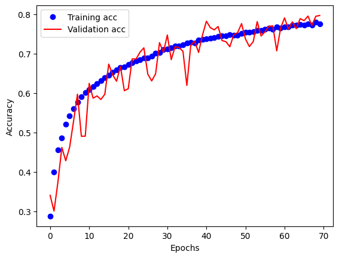

```python
import matplotlib.pyplot as plt
%matplotlib inline

acc = history.history['acc']
val_acc = history.history['val_acc']

epochs = range(len(acc))

plt.plot(epochs, acc, 'bo', label='Training acc')
plt.plot(epochs, val_acc, 'r', label='Validation acc')
plt.xlabel('Epochs')
plt.ylabel('Accuracy')
plt.legend()
plt.show()
```

## 3. Train (again) and evaluate the model

- To this end, you have found the "best" hyper-parameters.
- Now, fix the hyper-parameters and train the network on the entire training set (all the 50K training samples)
- Evaluate your model on the test set.

Why? Previously, you used 40K samples for training; you wasted 10K samples for the sake of hyper-parameter tuning. Now you already know the hyper-parameters, so why not using all the 50K samples for training?

```python
# <Compile your model again (using the same hyper-parameters)>
# <Train your model on the entire training set (50K samples)>
# <Use (x_train, y_train_vec) instead of (x_tr, y_tr)>
# <Do NOT use the validation_data option (because now you do not have validation data)>

from keras.layers import Conv2D, MaxPooling2D, Flatten, Dense
from keras.models import Sequential
from keras import layers
from keras import optimizers

model = Sequential()
# model.add(Conv2D(32, (3, 3), activation='relu', padding='same', input_shape=(32, 32, 3)))
model.add(Conv2D(32, (3, 3), padding='same', input_shape=(32, 32, 3)))
model.add(Conv2D(32, (3, 3), padding='same'))
model.add(layers.BatchNormalization())
model.add(layers.Activation('relu'))
model.add(MaxPooling2D((2, 2)))

model.add(Conv2D(64, (3, 3), padding='same'))
model.add(Conv2D(64, (3, 3), padding='same'))
model.add(layers.BatchNormalization())
model.add(layers.Activation('relu'))
model.add(MaxPooling2D((2, 2)))

model.add(Conv2D(128, (3, 3), padding='same'))
model.add(Conv2D(128, (3, 3), padding='same'))
model.add(Conv2D(128, (3, 3), padding='same'))
model.add(layers.BatchNormalization())
model.add(layers.Activation('relu'))
model.add(MaxPooling2D((2, 2)))

model.add(Conv2D(256, (3, 3), padding='same'))
model.add(Conv2D(256, (3, 3), padding='same'))
model.add(Conv2D(256, (3, 3), padding='same'))
model.add(layers.BatchNormalization())
model.add(layers.Activation('relu'))
model.add(MaxPooling2D((2, 2)))

model.add(Conv2D(256, (3, 3), padding='same'))
model.add(Conv2D(256, (3, 3), padding='same'))
model.add(Conv2D(256, (3, 3), padding='same'))
model.add(layers.BatchNormalization())
model.add(layers.Activation('relu'))
model.add(MaxPooling2D((2, 2)))

model.add(Flatten())
model.add(layers.Dropout(0.3))
model.add(Dense(128, activation='relu'))
model.add(Dense(10, activation='softmax'))

model.summary()

learning_rate = 1e-3

model.compile(loss='categorical_crossentropy',
              optimizer=optimizers.RMSprop(learning_rate=learning_rate),
              metrics=['acc'])
history = model.fit(train_generator, batch_size=32, epochs=70, validation_data=val_generator)
```

```
Model: "sequential"
```

```
┏━━━━━━━━━━━━━━━━━━━━━━━━━━━━━━━━━┳━━━━━━━━━━━━━━━━━━━━━━━━┳━━━━━━━━━━━━━━━┓
┃ Layer (type)                    ┃ Output Shape           ┃       Param # ┃
┡━━━━━━━━━━━━━━━━━━━━━━━━━━━━━━━━━╇━━━━━━━━━━━━━━━━━━━━━━━━╇━━━━━━━━━━━━━━━┩
│ conv2d (Conv2D)                 │ (None, 32, 32, 32)     │           896 │
├─────────────────────────────────┼────────────────────────┼───────────────┤
│ conv2d_1 (Conv2D)               │ (None, 32, 32, 32)     │         9,248 │
├─────────────────────────────────┼────────────────────────┼───────────────┤
│ batch_normalization             │ (None, 32, 32, 32)     │           128 │
│ (BatchNormalization)            │                        │               │
├─────────────────────────────────┼────────────────────────┼───────────────┤
│ activation (Activation)         │ (None, 32, 32, 32)     │             0 │
├─────────────────────────────────┼────────────────────────┼───────────────┤
│ max_pooling2d (MaxPooling2D)    │ (None, 16, 16, 32)     │             0 │
├─────────────────────────────────┼────────────────────────┼───────────────┤
│ conv2d_2 (Conv2D)               │ (None, 16, 16, 64)     │        18,496 │
├─────────────────────────────────┼────────────────────────┼───────────────┤
│ conv2d_3 (Conv2D)               │ (None, 16, 16, 64)     │        36,928 │
├─────────────────────────────────┼────────────────────────┼───────────────┤
│ batch_normalization_1           │ (None, 16, 16, 64)     │           256 │
│ (BatchNormalization)            │                        │               │
├─────────────────────────────────┼────────────────────────┼───────────────┤
│ activation_1 (Activation)       │ (None, 16, 16, 64)     │             0 │
├─────────────────────────────────┼────────────────────────┼───────────────┤
│ max_pooling2d_1 (MaxPooling2D)  │ (None, 8, 8, 64)       │             0 │
├─────────────────────────────────┼────────────────────────┼───────────────┤
│ conv2d_4 (Conv2D)               │ (None, 8, 8, 128)      │        73,856 │
├─────────────────────────────────┼────────────────────────┼───────────────┤
│ conv2d_5 (Conv2D)               │ (None, 8, 8, 128)      │       147,584 │
├─────────────────────────────────┼────────────────────────┼───────────────┤
│ conv2d_6 (Conv2D)               │ (None, 8, 8, 128)      │       147,584 │
├─────────────────────────────────┼────────────────────────┼───────────────┤
│ batch_normalization_2           │ (None, 8, 8, 128)      │           512 │
│ (BatchNormalization)            │                        │               │
├─────────────────────────────────┼────────────────────────┼───────────────┤
│ activation_2 (Activation)       │ (None, 8, 8, 128)      │             0 │
├─────────────────────────────────┼────────────────────────┼───────────────┤
│ max_pooling2d_2 (MaxPooling2D)  │ (None, 4, 4, 128)      │             0 │
├─────────────────────────────────┼────────────────────────┼───────────────┤
│ conv2d_7 (Conv2D)               │ (None, 4, 4, 256)      │       295,168 │
├─────────────────────────────────┼────────────────────────┼───────────────┤
```

[output cut: 17 more lines]

```
│ batch_normalization_4           │ (None, 2, 2, 256)      │         1,024 │
│ (BatchNormalization)            │                        │               │
├─────────────────────────────────┼────────────────────────┼───────────────┤
│ activation_4 (Activation)       │ (None, 2, 2, 256)      │             0 │
├─────────────────────────────────┼────────────────────────┼───────────────┤
│ max_pooling2d_4 (MaxPooling2D)  │ (None, 1, 1, 256)      │             0 │
├─────────────────────────────────┼────────────────────────┼───────────────┤
│ flatten (Flatten)               │ (None, 256)            │             0 │
├─────────────────────────────────┼────────────────────────┼───────────────┤
│ dropout (Dropout)               │ (None, 256)            │             0 │
├─────────────────────────────────┼────────────────────────┼───────────────┤
│ dense (Dense)                   │ (None, 128)            │        32,896 │
├─────────────────────────────────┼────────────────────────┼───────────────┤
│ dense_1 (Dense)                 │ (None, 10)             │         1,290 │
└─────────────────────────────────┴────────────────────────┴───────────────┘
```

```
 Total params: 3,717,290 (14.18 MB)
```

```
 Trainable params: 3,715,818 (14.17 MB)
```

```
 Non-trainable params: 1,472 (5.75 KB)
```

[output not shown]

[output cut: 15 more lines]

[output not shown]

### 3.2. Evaluate the model on the test set

Do NOT used the test set until now. Make sure that your model parameters and hyper-parameters are independent of the test set.

```python
x_test_norm = x_test.astype('float32') / 255.0
loss_and_acc = model.evaluate(x_test_norm, y_test_vec)
print('loss = ' + str(loss_and_acc[0]))
print('accuracy = ' + str(loss_and_acc[1]))
```

```
313/313 ━━━━━━━━━━━━━━━━━━━━ 3s 6ms/step - acc: 0.7851 - loss: 0.6635
loss = 0.6472465395927429
accuracy = 0.7901999950408936
```

### Discussion

Evaluate the model on the test set. Performance is acceptable with 79% accuracy. If ephoch number increase even more up to 80 or 100, accuracy is most likely increased to 80%+.(cannot test due to limited access to GPU in Colab).